# Modeling of Music Ratings

Brenndan Olson

We are going to be adding some continous data to our person table, and use that to build some models. First I am going to run all of the code from the previous work I was doing with this data

```r
suppressWarnings(library(caret))
suppressWarnings(library(knitr))
suppressWarnings(library(dplyr))
suppressWarnings(library(tidyverse))
purl("insights.Rmd", output = "part1.r")
```

```
##
##
## processing file: insights.Rmd
```

[output not shown]

```
## output file: part1.r
```

```
## [1] "part1.r"
```

```r
source("part1.r")
```

First, I am going to add a column avg_rating to the person table with a function called get_average_ratings, that will take in the pseudonyms as an argument and determine the average rating for each pseudonym

```r
get_average_ratings <- function(pseudonyms) {
  x <- c()
  for(i in pseudonyms){
    avg_rating <-mean(ratings$rating[ratings$pseudonym == i])
    x <- c(x,avg_rating)
  }
  return(x)
}
```

I am now going to call that function on the pseudonym column of person, and I am going to omit any NA values given to us because it causes a error later on. That person with the NA did not do the music survey and cannot provide us any helpful information on this analysis. At the same time I do not want to lose all of their data, so I will use a new table called person_for_model to omit the NA value peacefully.

```r
avg_song_ratings <- get_average_ratings(person$pseudonym)
person <- dplyr::mutate(person,avg_song_rating = avg_song_ratings)
person_for_model <- person %>%
  na.omit(person$avg_song_rating)
```

```r
index <- createDataPartition(person_for_model$avg_song_rating, p = 0.75, list = FALSE)
train <- person_for_model[index, ]
test <- person_for_model[-index, ]
```

We can now use the train data to create some models, and try to discover any independent variables that can help predict avg_song_rating. The biggest thing we are looking at are the p-values, and the smaller it is the more it can predict average song rating. The larger values mean that variable does not predict it, and should be taken out to make the model more precise.

```r
model <- lm(train, formula = avg_song_rating~academic_major + academic_level + year_born)
summary(model)
```

```
##
## Call:
## lm(formula = avg_song_rating ~ academic_major + academic_level +
##     year_born, data = train)
##
## Residuals:
##     Min      1Q  Median      3Q     Max
## -1.5263 -0.6488 -0.1722  0.4089  2.3808
##
## Coefficients:
##                                              Estimate Std. Error t value
## (Intercept)                                 3.3601197 60.8096100   0.055
## academic_majorComputer Information Systems  3.8215350  1.5635206   2.444
## academic_majorComputer Science              0.9510732  1.1104897   0.856
## academic_majorMath                          1.1259890  1.2830169   0.878
## academic_levelSenior                       -0.0381499  0.4167454  -0.092
## academic_levelSophomore                    -0.1423645  1.1728903  -0.121
## year_born                                   0.0006892  0.0304997   0.023
##                                            Pr(>|t|)
## (Intercept)                                  0.9564
## academic_majorComputer Information Systems   0.0216 *
## academic_majorComputer Science               0.3996
## academic_majorMath                           0.3882
## academic_levelSenior                         0.9278
## academic_levelSophomore                      0.9043
## year_born                                    0.9821
## ---
## Signif. codes:  0 '***' 0.001 '**' 0.01 '*' 0.05 '.' 0.1 ' ' 1
##
## Residual standard error: 1.08 on 26 degrees of freedom
## Multiple R-squared:  0.2293, Adjusted R-squared:  0.05139
## F-statistic: 1.289 on 6 and 26 DF,  p-value: 0.2968
```

The p-value for academic_level is very high, so I am going to run the model again without it

```r
model <- lm(train, formula = avg_song_rating~academic_major + year_born)
summary(model)
```

```
##
## Call:
## lm(formula = avg_song_rating ~ academic_major + year_born, data = train)
##
## Residuals:
##     Min      1Q  Median      3Q     Max
## -1.5331 -0.6598 -0.1519  0.3806  2.4065
##
## Coefficients:
##                                             Estimate Std. Error t value
## (Intercept)                                 2.374901  54.784480   0.043
## academic_majorComputer Information Systems  3.826754   1.502748   2.547
## academic_majorComputer Science              0.962128   1.061464   0.906
## academic_majorMath                          1.154269   1.213204   0.951
## year_born                                   0.001164   0.027442   0.042
##                                            Pr(>|t|)
## (Intercept)                                  0.9657
## academic_majorComputer Information Systems   0.0167 *
## academic_majorComputer Science               0.3724
## academic_majorMath                           0.3495
## year_born                                    0.9665
## ---
## Signif. codes:  0 '***' 0.001 '**' 0.01 '*' 0.05 '.' 0.1 ' ' 1
##
## Residual standard error: 1.041 on 28 degrees of freedom
## Multiple R-squared:  0.2287, Adjusted R-squared:  0.1185
## F-statistic: 2.075 on 4 and 28 DF,  p-value: 0.1109
```

The p-value for year_born is quite high, but without it there would only be a categorical variable, and the equation would only make one value for each category, which wouldn’t be very predictive.

Now that we have a model, we can compare the values our model gives us to those inside the test table. I an going to create a function that goes through every entry in the test table and does the calculation for avg_song_rating depending on the academic major, and adds the intercept to get y^. We can compare those to the actual values in the table and determine how accurate the model is.

```r
test_model <- function(model)
{
  modeled_ratings <- c()
  for(i in 1:9)
  {
    x<-0
    if(test$academic_major[i] == "Computer Information Systems")
      x<-model$coefficients[2]
    if(test$academic_major[i] == "Computer Science")
      x<-model$coefficients[3]
    if(test$academic_major[i] == "Math")
      x<-model$coefficients[4]
    yhat <- x + test$year_born[i]*model$coefficients[5] + model$coefficients[1]
    modeled_ratings <- c(modeled_ratings,yhat)
  }
  return(modeled_ratings)
}
modeled_avg_ratings <- test_model(model)
test_avg_ratings <- test$avg_song_rating
```

I am going to plot the two on a scatter plot, and since this is just a quick visualization I am going to use the plot() function, because it is easy to add more graphs inside one plot.

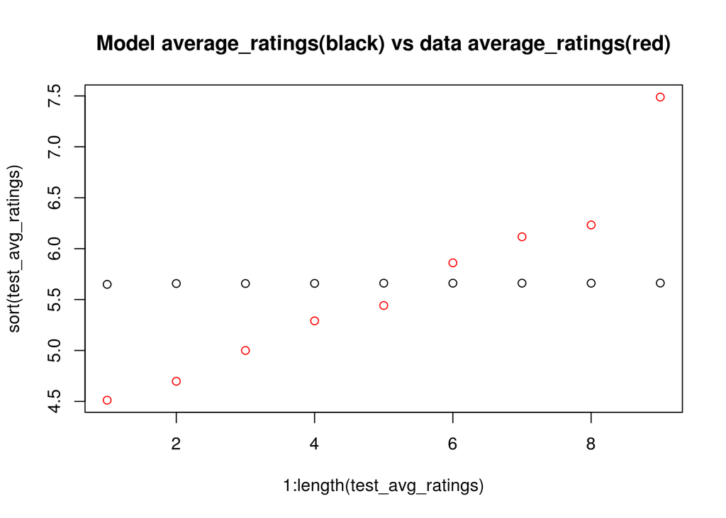

```r
plot(x=1:length(test_avg_ratings),y=sort(test_avg_ratings),type="p",col="red")
  points(x=1:length(modeled_avg_ratings),y=sort(modeled_avg_ratings))
  title(main = "Model average_ratings(black) vs data average_ratings(red)")
```

Since the data inside test only had data from Computer Science majors, they all have the same value. Unfortunately there was only a few other instances of CINS or MATH, so by chance it was not included in test. These two variables are a horrible predictor of average rating, and this should have been expected because of the high p-values in the model.

To be fair a accurate model would require a lot more data to be collected, and not within a specific group. Upper-classmen STEM majors inside one class would not be near enough to figure out how someone would rate music. If enough data was collected on people within each major, and for every major, then we could start to determine the relationship between that and their ratings of music.